# Лабораторная работа: Импорт и профилирование данных

Шевчук Д.Р., 02271-ДМ

2026-10-19

# Задание 1

```r
library(tidyverse)
library(janitor)
library(skimr)
library(visdat)
library(DataExplorer)
```

```r
read_lines("../data/raw/AirQualityUCI.csv", n_max = 5)
```

```
## [1] "Date;Time;CO(GT);PT08.S1(CO);NMHC(GT);C6H6(GT);PT08.S2(NMHC);NOx(GT);PT08.S3(NOx);NO2(GT);PT08.S4(NO2);PT08.S5(O3);T;RH;AH;;"
## [2] "10/03/2004;18.00.00;2,6;1360;150;11,9;1046;166;1056;113;1692;1268;13,6;48,9;0,7578;;"
## [3] "10/03/2004;19.00.00;2;1292;112;9,4;955;103;1174;92;1559;972;13,3;47,7;0,7255;;"
## [4] "10/03/2004;20.00.00;2,2;1402;88;9,0;939;131;1140;114;1555;1074;11,9;54,0;0,7502;;"
## [5] "10/03/2004;21.00.00;2,2;1376;80;9,2;948;172;1092;122;1584;1203;11,0;60,0;0,7867;;"
```

```r
read_lines("../data/raw/AirQualityUCI.csv", skip = 9355)
```

```
##   [1] "04/04/2005;12.00.00;2,4;1142;-200;12,4;1063;293;603;175;1241;1092;26,9;18,3;0,6406;;"
##   [2] "04/04/2005;13.00.00;2,1;1003;-200;9,5;961;235;702;156;1041;770;28,3;13,5;0,5139;;"
##   [3] "04/04/2005;14.00.00;2,2;1071;-200;11,9;1047;265;654;168;1129;816;28,5;13,1;0,5028;;"
##   [4] ";;;;;;;;;;;;;;;;"
##   [5] ";;;;;;;;;;;;;;;;"
##   [6] ";;;;;;;;;;;;;;;;"
##   [7] ";;;;;;;;;;;;;;;;"
##   [8] ";;;;;;;;;;;;;;;;"
##   [9] ";;;;;;;;;;;;;;;;"
##  [10] ";;;;;;;;;;;;;;;;"
##  [11] ";;;;;;;;;;;;;;;;"
##  [12] ";;;;;;;;;;;;;;;;"
##  [13] ";;;;;;;;;;;;;;;;"
##  [14] ";;;;;;;;;;;;;;;;"
##  [15] ";;;;;;;;;;;;;;;;"
```

[output cut: 102 more lines]

```r
guess_encoding("../data/raw/AirQualityUCI.csv")
```

```
## # A tibble: 1 × 2
##   encoding confidence
##   <chr>         <dbl>
## 1 ASCII             1
```

# Задание 2

## Параметры файла

[output not shown]

# Задание 3

## Импорт основного набора

```r
df_raw <- read_csv2(
  "../data/raw/AirQualityUCI.csv",
  na = c("", "NA", "-200"),
  col_types = cols(Date = col_character(), Time = col_character())
)
```

```
## ℹ Using "','" as decimal and "'.'" as grouping mark. Use `read_delim()` for more control.
```

```r
glimpse(df_raw) # Первое представление данных (количество строк/столбцов и краткая информация по каждому столбцу)
```

```
## Rows: 9,471
## Columns: 17
## $ Date            <chr> "10/03/2004", "10/03/2004", "10/03/2004", "10/03/2004"…
## $ Time            <chr> "18.00.00", "19.00.00", "20.00.00", "21.00.00", "22.00…
## $ `CO(GT)`        <dbl> 2.6, 2.0, 2.2, 2.2, 1.6, 1.2, 1.2, 1.0, 0.9, 0.6, NA, …
## $ `PT08.S1(CO)`   <dbl> 1360, 1292, 1402, 1376, 1272, 1197, 1185, 1136, 1094, …
## $ `NMHC(GT)`      <dbl> 150, 112, 88, 80, 51, 38, 31, 31, 24, 19, 14, 8, 16, 2…
## $ `C6H6(GT)`      <dbl> 11.9, 9.4, 9.0, 9.2, 6.5, 4.7, 3.6, 3.3, 2.3, 1.7, 1.3…
## $ `PT08.S2(NMHC)` <dbl> 1046, 955, 939, 948, 836, 750, 690, 672, 609, 561, 527…
## $ `NOx(GT)`       <dbl> 166, 103, 131, 172, 131, 89, 62, 62, 45, NA, 21, 16, 3…
## $ `PT08.S3(NOx)`  <dbl> 1056, 1174, 1140, 1092, 1205, 1337, 1462, 1453, 1579, …
## $ `NO2(GT)`       <dbl> 113, 92, 114, 122, 116, 96, 77, 76, 60, NA, 34, 28, 48…
## $ `PT08.S4(NO2)`  <dbl> 1692, 1559, 1555, 1584, 1490, 1393, 1333, 1333, 1276, …
## $ `PT08.S5(O3)`   <dbl> 1268, 972, 1074, 1203, 1110, 949, 733, 730, 620, 501, …
## $ T               <dbl> 13.6, 13.3, 11.9, 11.0, 11.2, 11.2, 11.3, 10.7, 10.7, …
## $ RH              <dbl> 48.9, 47.7, 54.0, 60.0, 59.6, 59.2, 56.8, 60.0, 59.7, …
## $ AH              <dbl> 0.7578, 0.7255, 0.7502, 0.7867, 0.7888, 0.7848, 0.7603…
## $ ...16           <lgl> NA, NA, NA, NA, NA, NA, NA, NA, NA, NA, NA, NA, NA, NA…
## $ ...17           <lgl> NA, NA, NA, NA, NA, NA, NA, NA, NA, NA, NA, NA, NA, NA…
```

```r
spec(df_raw) # Подробнее о типах
problems(df_raw) # Какие проблемы возникли при считывании
```

```
## # A tibble: 0 × 5
## # ℹ 5 variables: row <int>, col <int>, expected <chr>, actual <chr>, file <chr>
```

## Пояснение параметров

[output not shown]

`problems(df_raw)` — Журнал ошибок парсинга — строки, которые readr не смог уложить в заявленные типы. Для каждой проблемы возвращает tibble со столбцами:

- `row` — номер строки файла;
- `col` — какой столбец сломался;
- `expected` — какой тип ожидался;
- `actual` — что реально пришло (например, текст `"NA"` вместо числа).

В данном случае `problems(df_raw)` — пустой. Это означает, что все строки файла успешно приведены к заявленным типам столбцов, данные потеряны не были.

# Задание 4

## Чтение с параметрами по умолчанию

```r
df_raw <- read_csv(
  "../data/raw/water.csv",
  show_col_types = FALSE
)
problems(df_raw)
```

```
## # A tibble: 31 × 5
##      row   col expected  actual    file
##    <int> <int> <chr>     <chr>     <chr>
##  1     3     7 1 columns 7 columns C:/Users/delta/Documents/GitHub/Import_and_p…
##  2     4     7 1 columns 7 columns C:/Users/delta/Documents/GitHub/Import_and_p…
##  3     5     7 1 columns 7 columns C:/Users/delta/Documents/GitHub/Import_and_p…
##  4     6     7 1 columns 7 columns C:/Users/delta/Documents/GitHub/Import_and_p…
##  5     7     7 1 columns 7 columns C:/Users/delta/Documents/GitHub/Import_and_p…
##  6     8     7 1 columns 7 columns C:/Users/delta/Documents/GitHub/Import_and_p…
##  7     9     7 1 columns 7 columns C:/Users/delta/Documents/GitHub/Import_and_p…
##  8    10     7 1 columns 7 columns C:/Users/delta/Documents/GitHub/Import_and_p…
##  9    11     7 1 columns 7 columns C:/Users/delta/Documents/GitHub/Import_and_p…
## 10    12     7 1 columns 7 columns C:/Users/delta/Documents/GitHub/Import_and_p…
## # ℹ 21 more rows
```

## Чтение с подбором

```r
path <- "../data/raw/water.csv"
txt <- iconv(
  readLines(path),
  from = "KOI8-R", to = "UTF-8") |> paste(collapse = "\n")
df_raw <- read_csv(
  txt,
  locale = locale(encoding = "UTF-8"),
  skip    = 2,
  comment = "Итого строк",
  na      = c("", "-", "нет"),
  col_types = cols(ID = col_character(), `Дата отбора` = col_character())
)
glimpse(df_raw)
```

```
## Rows: 30
## Columns: 7
## $ ID                            <chr> "В-001", "В-002", "В-003", "В-004", "В-0…
## $ Створ                         <chr> "Река Ока, г. Калуга", "Река Ока, г. Кал…
## $ `Дата отбора`                 <chr> "2025-04-07", "2025-04-14", "2025-04-21"…
## $ pH                            <dbl> 7.44, 7.27, 7.49, 6.98, NA, 7.19, 7.46, …
## $ `Растворённый кислород, мг/л` <dbl> 9.2, 7.7, 9.3, 6.7, 10.3, 9.2, 9.2, 7.9,…
## $ `Нитраты, мг/л`               <dbl> 3.52, NA, 3.08, NA, 3.92, 4.15, 1.46, 4.…
## $ Примечание                    <chr> NA, "отбор при дожде", NA, "отбор при до…
```

```r
spec(df_raw)
head(df_raw, 5)
```

```
## # A tibble: 5 × 7
##   ID    Створ         `Дата отбора`    pH Растворённый кислоро…¹ `Нитраты, мг/л`
##   <chr> <chr>         <chr>         <dbl>                  <dbl>           <dbl>
## 1 В-001 Река Ока, г.… 2025-04-07     7.44                    9.2            3.52
## 2 В-002 Река Ока, г.… 2025-04-14     7.27                    7.7           NA
## 3 В-003 Река Ока, г.… 2025-04-21     7.49                    9.3            3.08
## 4 В-004 Река Ока, г.… 2025-04-28     6.98                    6.7           NA
## 5 В-005 Река Ока, г.… 2025-05-05    NA                      10.3            3.92
## # ℹ abbreviated name: ¹`Растворённый кислород, мг/л`
## # ℹ 1 more variable: Примечание <chr>
```

```r
problems(df_raw)
```

```
## # A tibble: 0 × 5
## # ℹ 5 variables: row <int>, col <int>, expected <chr>, actual <chr>, file <chr>
```

[output not shown]

# Задание 5

## Имена, пустые строки и типы

### Таблица до

```r
df_raw <- read_csv2(
  "../data/raw/AirQualityUCI.csv",
  na = c("", "NA", "-200"),
  col_types = cols(Date = col_character(), Time = col_character())
)
```

```
## ℹ Using "','" as decimal and "'.'" as grouping mark. Use `read_delim()` for more control.
```

```r
glimpse(df_raw)
```

```
## Rows: 9,471
## Columns: 17
## $ Date            <chr> "10/03/2004", "10/03/2004", "10/03/2004", "10/03/2004"…
## $ Time            <chr> "18.00.00", "19.00.00", "20.00.00", "21.00.00", "22.00…
## $ `CO(GT)`        <dbl> 2.6, 2.0, 2.2, 2.2, 1.6, 1.2, 1.2, 1.0, 0.9, 0.6, NA, …
## $ `PT08.S1(CO)`   <dbl> 1360, 1292, 1402, 1376, 1272, 1197, 1185, 1136, 1094, …
## $ `NMHC(GT)`      <dbl> 150, 112, 88, 80, 51, 38, 31, 31, 24, 19, 14, 8, 16, 2…
## $ `C6H6(GT)`      <dbl> 11.9, 9.4, 9.0, 9.2, 6.5, 4.7, 3.6, 3.3, 2.3, 1.7, 1.3…
## $ `PT08.S2(NMHC)` <dbl> 1046, 955, 939, 948, 836, 750, 690, 672, 609, 561, 527…
## $ `NOx(GT)`       <dbl> 166, 103, 131, 172, 131, 89, 62, 62, 45, NA, 21, 16, 3…
## $ `PT08.S3(NOx)`  <dbl> 1056, 1174, 1140, 1092, 1205, 1337, 1462, 1453, 1579, …
## $ `NO2(GT)`       <dbl> 113, 92, 114, 122, 116, 96, 77, 76, 60, NA, 34, 28, 48…
## $ `PT08.S4(NO2)`  <dbl> 1692, 1559, 1555, 1584, 1490, 1393, 1333, 1333, 1276, …
## $ `PT08.S5(O3)`   <dbl> 1268, 972, 1074, 1203, 1110, 949, 733, 730, 620, 501, …
## $ T               <dbl> 13.6, 13.3, 11.9, 11.0, 11.2, 11.2, 11.3, 10.7, 10.7, …
## $ RH              <dbl> 48.9, 47.7, 54.0, 60.0, 59.6, 59.2, 56.8, 60.0, 59.7, …
## $ AH              <dbl> 0.7578, 0.7255, 0.7502, 0.7867, 0.7888, 0.7848, 0.7603…
## $ ...16           <lgl> NA, NA, NA, NA, NA, NA, NA, NA, NA, NA, NA, NA, NA, NA…
## $ ...17           <lgl> NA, NA, NA, NA, NA, NA, NA, NA, NA, NA, NA, NA, NA, NA…
```

### Таблица после

```r
df <- df_raw |>
  clean_names() |>
  remove_empty(which = c("rows", "cols")) |>
  mutate(
    datetime = parse_date_time(
      paste(date, time),
      orders = c("dmy HMS", "dmy HM"),
      tz     = "Asia/Irkutsk"
    ),
    .after = time
  )
sum(is.na(df$datetime))
```

```
## [1] 2
```

```r
print(df |> filter(is.na(datetime)) |> select(date, time))
```

```
## # A tibble: 2 × 2
##   date       time
##   <chr>      <chr>
## 1 28/03/2004 02.00.00
## 2 27/03/2005 02.00.00
```

```r
glimpse(df)
```

```
## Rows: 9,357
## Columns: 16
## $ date         <chr> "10/03/2004", "10/03/2004", "10/03/2004", "10/03/2004", "…
## $ time         <chr> "18.00.00", "19.00.00", "20.00.00", "21.00.00", "22.00.00…
## $ datetime     <dttm> 2004-03-10 18:00:00, 2004-03-10 19:00:00, 2004-03-10 20:…
## $ co_gt        <dbl> 2.6, 2.0, 2.2, 2.2, 1.6, 1.2, 1.2, 1.0, 0.9, 0.6, NA, 0.7…
## $ pt08_s1_co   <dbl> 1360, 1292, 1402, 1376, 1272, 1197, 1185, 1136, 1094, 101…
## $ nmhc_gt      <dbl> 150, 112, 88, 80, 51, 38, 31, 31, 24, 19, 14, 8, 16, 29, …
## $ c6h6_gt      <dbl> 11.9, 9.4, 9.0, 9.2, 6.5, 4.7, 3.6, 3.3, 2.3, 1.7, 1.3, 1…
## $ pt08_s2_nmhc <dbl> 1046, 955, 939, 948, 836, 750, 690, 672, 609, 561, 527, 5…
## $ n_ox_gt      <dbl> 166, 103, 131, 172, 131, 89, 62, 62, 45, NA, 21, 16, 34, …
## $ pt08_s3_n_ox <dbl> 1056, 1174, 1140, 1092, 1205, 1337, 1462, 1453, 1579, 170…
## $ no2_gt       <dbl> 113, 92, 114, 122, 116, 96, 77, 76, 60, NA, 34, 28, 48, 8…
## $ pt08_s4_no2  <dbl> 1692, 1559, 1555, 1584, 1490, 1393, 1333, 1333, 1276, 123…
## $ pt08_s5_o3   <dbl> 1268, 972, 1074, 1203, 1110, 949, 733, 730, 620, 501, 445…
## $ t            <dbl> 13.6, 13.3, 11.9, 11.0, 11.2, 11.2, 11.3, 10.7, 10.7, 10.…
## $ rh           <dbl> 48.9, 47.7, 54.0, 60.0, 59.6, 59.2, 56.8, 60.0, 59.7, 60.…
## $ ah           <dbl> 0.7578, 0.7255, 0.7502, 0.7867, 0.7888, 0.7848, 0.7603, 0…
```

При сборке метки времени не удалось преобразовать 2 значения: строки 28.03.2004 02:00:00 и 27.03.2005 02:00:00. Причина — переход на летнее время: локальное время 02:00:00 в эти даты не существует ни в зоне Europe/Rome, ни в зоне Asia/Irkutsk, поскольку в 2004–2005 годах обе территории использовали переход на летнее время по единому европейскому правилу (последнее воскресенье марта, часы с 02:00 переводятся на 03:00). Результат не зависит от выбора часового пояса из указанных.

# Задание 6

## Профилирование

```r
skim(df)
```

Data summary

| Name | df |
| --- | --- |
| Number of rows | 9357 |
| Number of columns | 16 |
| _______________________ |  |
| Column type frequency: |  |
| character | 2 |
| numeric | 13 |
| POSIXct | 1 |
| ________________________ |  |
| Group variables | None |

**Variable type: character**

| skim_variable | n_missing | complete_rate | min | max | empty | n_unique | whitespace |
| --- | --- | --- | --- | --- | --- | --- | --- |
| date | 0 | 1 | 10 | 10 | 0 | 391 | 0 |
| time | 0 | 1 | 8 | 8 | 0 | 24 | 0 |

**Variable type: numeric**

| skim_variable | n_missing | complete_rate | mean | sd | p0 | p25 | p50 | p75 | p100 | hist |
| --- | --- | --- | --- | --- | --- | --- | --- | --- | --- | --- |
| co_gt | 1592 | 0.83 | -0.22 | 21.80 | -200.00 | 1.00 | 1.8 | 2.90 | 11.90 | ▁▁▁▁▇ |
| pt08_s1_co | 366 | 0.96 | 1099.83 | 217.08 | 647.00 | 937.00 | 1063.0 | 1231.00 | 2040.00 | ▃▇▃▁▁ |
| nmhc_gt | 8443 | 0.10 | 218.81 | 204.46 | 7.00 | 67.00 | 150.0 | 297.00 | 1189.00 | ▇▂▁▁▁ |
| c6h6_gt | 0 | 1.00 | 1.87 | 41.38 | -200.00 | 4.00 | 7.9 | 13.60 | 63.70 | ▁▁▁▇▅ |
| pt08_s2_nmhc | 366 | 0.96 | 939.15 | 266.83 | 383.00 | 734.50 | 909.0 | 1116.00 | 2214.00 | ▅▇▃▁▁ |
| n_ox_gt | 1639 | 0.82 | 246.90 | 212.98 | 2.00 | 98.00 | 180.0 | 326.00 | 1479.00 | ▇▂▁▁▁ |
| pt08_s3_n_ox | 366 | 0.96 | 835.49 | 256.82 | 322.00 | 658.00 | 806.0 | 969.50 | 2683.00 | ▇▇▁▁▁ |
| no2_gt | 1642 | 0.82 | 113.09 | 48.37 | 2.00 | 78.00 | 109.0 | 142.00 | 340.00 | ▃▇▃▁▁ |
| pt08_s4_no2 | 366 | 0.96 | 1456.26 | 346.21 | 551.00 | 1227.00 | 1463.0 | 1674.00 | 2775.00 | ▂▇▇▂▁ |
| pt08_s5_o3 | 366 | 0.96 | 1022.91 | 398.48 | 221.00 | 731.50 | 963.0 | 1273.50 | 2523.00 | ▃▇▅▂▁ |
| t | 366 | 0.96 | 18.32 | 8.83 | -1.90 | 11.80 | 17.8 | 24.40 | 44.60 | ▂▇▇▃▁ |
| rh | 366 | 0.96 | 49.23 | 17.32 | 9.20 | 35.80 | 49.6 | 62.50 | 88.70 | ▂▆▇▆▂ |
| ah | 366 | 0.96 | 1.03 | 0.40 | 0.18 | 0.74 | 1.0 | 1.31 | 2.23 | ▃▇▇▃▁ |

**Variable type: POSIXct**

| skim_variable | n_missing | complete_rate | min | max | median | n_unique |
| --- | --- | --- | --- | --- | --- | --- |
| datetime | 2 | 1 | 2004-03-10 18:00:00 | 2005-04-04 14:00:00 | 2004-09-21 16:00:00 | 9355 |

## Полнота по столбцам

[output not shown]

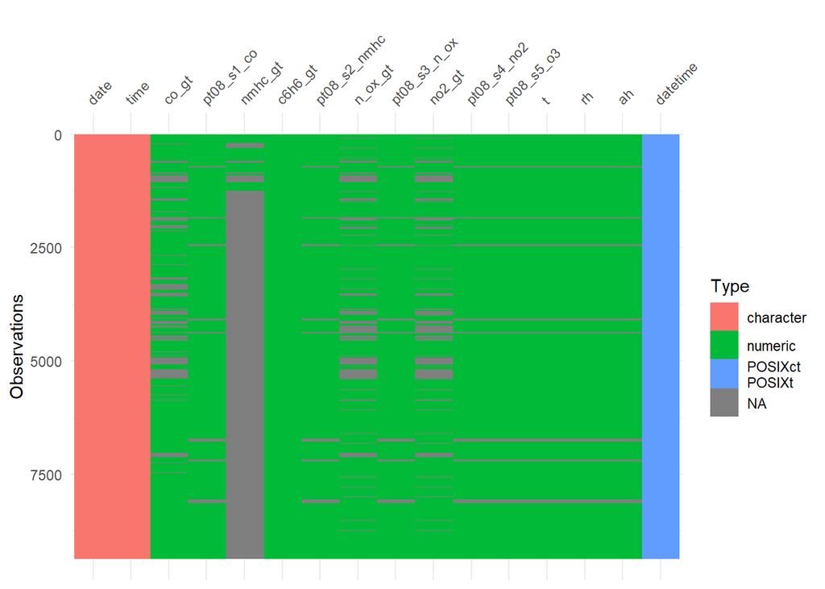

```r
vis_dat(df)            # карта типов: каждый столбец одним цветом
```

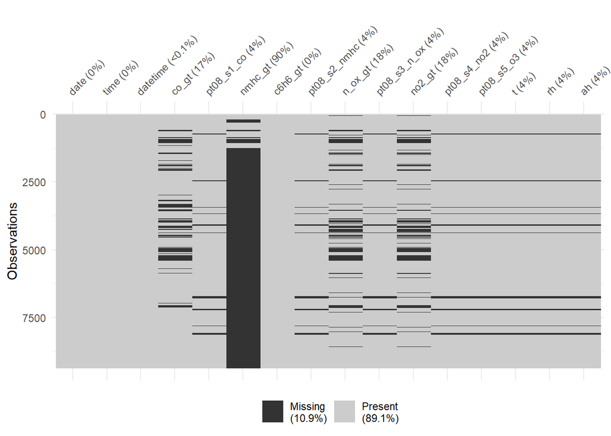

```r
vis_miss(df)           # карта пропусков: темные полосы = NA
```

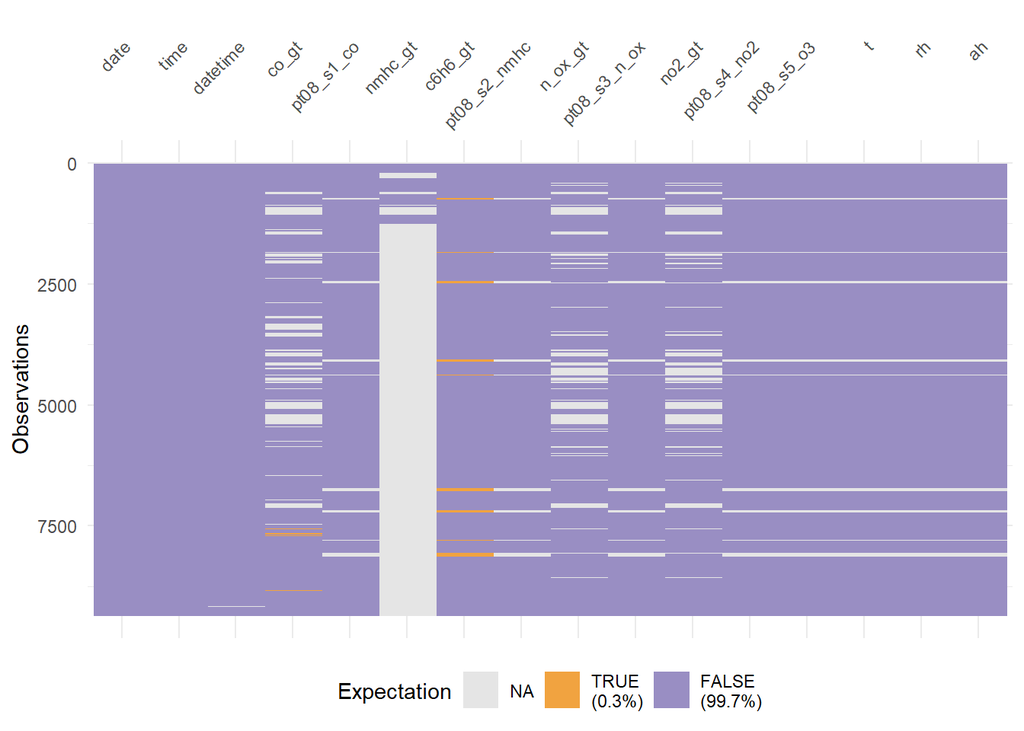

```r
vis_expect(df, ~ .x == -200) +
  theme(axis.text.x = element_text(angle = 45, hjust = 1))   # подсветить ячейки со значением -200
```

## Перечень столбцов с подозрительными диапазонами

[output not shown]

```r
create_report(data = df, output_file = "./air_quality_profile.html")
```

```
##
##
## processing file: report.rmd
```

[output not shown]

[output not shown]

[output not shown]

[output not shown]

[output not shown]

[output not shown]

[output not shown]

[output not shown]

```
## output file: C:/Users/delta/Documents/GitHub/Import_and_profiling_of_the_dataset/lab_2/project/reports/report.knit.md
```

[output not shown]

```
##
## Output created: air_quality_profile.html
```

```r
count(get_dupes(df))
```

```
## No variable names specified - using all columns.
```

```
## No duplicate combinations found of: date, time, datetime, co_gt, pt08_s1_co, nmhc_gt, c6h6_gt, pt08_s2_nmhc, n_ox_gt, ... and 7 other variables
```

```
## # A tibble: 1 × 1
##       n
##   <int>
## 1     0
```

# Задание 7

## Таблица найденных проблем

[output not shown]

## Вывод

Самая серьезная проблема — скрытые пропуски со значением −200 (строки 1–2): они молча искажают данные статистики и проходят незамеченными через стандартные проверки, поскольку числятся валидными значениями; до замены на NA любые средние и модели по таким столбцам недостоверны. Вторая по значимости — почти полностью пустой столбец `nmhc_gt`, который придется исключить из анализа целиком. Третья — кластерный характер пропусков (строки 3–4): потери сгруппированы в периоды простоя, а не размазаны случайно, поэтому удаление строк вместо учета простоя сместило бы оценку сезонной динамики. Проблемы дат (строка 5) и имени столбца (строка 6) технически просты и уже локализованы. Остальные пункты проверки точности/уникальности — они не блокируют анализ, но отделяют реальные пики загрязнения от ошибок датчиков.